# Introduction

In this project, the basic information on Titanic passengers is given, including class, sex, age and fare. I'm trying to explore the relation between suvival status and the passengers given information and conclude on which condition, the passenger has the most possibility to survive.

```python
# read data with panda DataFrame
import pandas as pd

titanic_df = pd.read_csv('titanic-data.csv')
```

```python
titanic_df.head()
```

|  | PassengerId | Survived | Pclass | Name | Sex | Age | SibSp | Parch | Ticket | Fare | Cabin | Embarked |
| --- | --- | --- | --- | --- | --- | --- | --- | --- | --- | --- | --- | --- |
| 0 | 1 | 0 | 3 | Braund, Mr. Owen Harris | male | 22.0 | 1 | 0 | A/5 21171 | 7.2500 | NaN | S |
| 1 | 2 | 1 | 1 | Cumings, Mrs. John Bradley (Florence Briggs Th... | female | 38.0 | 1 | 0 | PC 17599 | 71.2833 | C85 | C |
| 2 | 3 | 1 | 3 | Heikkinen, Miss. Laina | female | 26.0 | 0 | 0 | STON/O2. 3101282 | 7.9250 | NaN | S |
| 3 | 4 | 1 | 1 | Futrelle, Mrs. Jacques Heath (Lily May Peel) | female | 35.0 | 1 | 0 | 113803 | 53.1000 | C123 | S |
| 4 | 5 | 0 | 3 | Allen, Mr. William Henry | male | 35.0 | 0 | 0 | 373450 | 8.0500 | NaN | S |

```python
titanic_df.describe()
```

|  | PassengerId | Survived | Pclass | Age | SibSp | Parch | Fare |
| --- | --- | --- | --- | --- | --- | --- | --- |
| count | 891.000000 | 891.000000 | 891.000000 | 714.000000 | 891.000000 | 891.000000 | 891.000000 |
| mean | 446.000000 | 0.383838 | 2.308642 | 29.699118 | 0.523008 | 0.381594 | 32.204208 |
| std | 257.353842 | 0.486592 | 0.836071 | 14.526497 | 1.102743 | 0.806057 | 49.693429 |
| min | 1.000000 | 0.000000 | 1.000000 | 0.420000 | 0.000000 | 0.000000 | 0.000000 |
| 25% | 223.500000 | 0.000000 | 2.000000 | 20.125000 | 0.000000 | 0.000000 | 7.910400 |
| 50% | 446.000000 | 0.000000 | 3.000000 | 28.000000 | 0.000000 | 0.000000 | 14.454200 |
| 75% | 668.500000 | 1.000000 | 3.000000 | 38.000000 | 1.000000 | 0.000000 | 31.000000 |
| max | 891.000000 | 1.000000 | 3.000000 | 80.000000 | 8.000000 | 6.000000 | 512.329200 |

```python
# summarize missing data and check the quality of data
titanic_df.isnull().sum()
```

```
PassengerId      0
Survived         0
Pclass           0
Name             0
Sex              0
Age            177
SibSp            0
Parch            0
Ticket           0
Fare             0
Cabin          687
Embarked         2
dtype: int64
```

Age information is missing for 177 records of a total of 891 records. This may cause the inaccuracy to age-related analysis below. Carbin information is missing for most of the records (687 of 891). So the carbin won't be analized in details, since missing data will be misleading and biased. For the age information, I'm not going to fill it automatically, because there is no good way to guess a passenger's age based on the given information. On some other cases, the automatically filling might be a good option. Say, for a house price dataset, if some of the price information is missing, we can still fill it based on other information like sqft, year built, neighborhood or by comparing with similar house. In this project, I'll just ignore those records with missing age information. For the following analysis, I'll use functions like groupby or matplotlib for visualization. Those functions will exclude the null data automatically so it won't cause any issues to those records with full information.

```python
titanic_df.max(axis=0)
```

```
PassengerId    891.0000
Survived         1.0000
Pclass           3.0000
Age             80.0000
SibSp            8.0000
Parch            6.0000
Fare           512.3292
dtype: float64
```

```python
print('Number of survived and dead')
titanic_df['Survived'].value_counts()
```

```
Number of survived and dead
```

```
0    549
1    342
Name: Survived, dtype: int64
```

```python
print('Number of female and males')
titanic_df['Sex'].value_counts()
```

```
Number of female and males
```

```
male      577
female    314
Name: Sex, dtype: int64
```

```python
cols_to_norm = ['Fare']
titanic_df['Norm_Fare'] = titanic_df[cols_to_norm].apply(lambda x: (x - x.mean()) / (x.max() - x.min()))
titanic_df.head()
```

|  | PassengerId | Survived | Pclass | Name | Sex | Age | SibSp | Parch | Ticket | Fare | Cabin | Embarked | Norm_Fare |
| --- | --- | --- | --- | --- | --- | --- | --- | --- | --- | --- | --- | --- | --- |
| 0 | 1 | 0 | 3 | Braund, Mr. Owen Harris | male | 22.0 | 1 | 0 | A/5 21171 | 7.2500 | NaN | S | -0.048707 |
| 1 | 2 | 1 | 1 | Cumings, Mrs. John Bradley (Florence Briggs Th... | female | 38.0 | 1 | 0 | PC 17599 | 71.2833 | C85 | C | 0.076277 |
| 2 | 3 | 1 | 3 | Heikkinen, Miss. Laina | female | 26.0 | 0 | 0 | STON/O2. 3101282 | 7.9250 | NaN | S | -0.047390 |
| 3 | 4 | 1 | 1 | Futrelle, Mrs. Jacques Heath (Lily May Peel) | female | 35.0 | 1 | 0 | 113803 | 53.1000 | C123 | S | 0.040786 |
| 4 | 5 | 0 | 3 | Allen, Mr. William Henry | male | 35.0 | 0 | 0 | 373450 | 8.0500 | NaN | S | -0.047146 |

According to the review suggestion, creating the more descriptive labels for "survival" and "class"

```python
titanic_df["Survival"] = titanic_df.Survived.map({0: "Died", 1: "Survived"})
titanic_df["Class"] = titanic_df.Pclass.map({1: "First Class", 2: "Second Class", 3: "Third Class"})
titanic_df.head()
```

|  | PassengerId | Survived | Pclass | Name | Sex | Age | SibSp | Parch | Ticket | Fare | Cabin | Embarked | Norm_Fare | Survival | Class |
| --- | --- | --- | --- | --- | --- | --- | --- | --- | --- | --- | --- | --- | --- | --- | --- |
| 0 | 1 | 0 | 3 | Braund, Mr. Owen Harris | male | 22.0 | 1 | 0 | A/5 21171 | 7.2500 | NaN | S | -0.048707 | Died | Third Class |
| 1 | 2 | 1 | 1 | Cumings, Mrs. John Bradley (Florence Briggs Th... | female | 38.0 | 1 | 0 | PC 17599 | 71.2833 | C85 | C | 0.076277 | Survived | First Class |
| 2 | 3 | 1 | 3 | Heikkinen, Miss. Laina | female | 26.0 | 0 | 0 | STON/O2. 3101282 | 7.9250 | NaN | S | -0.047390 | Survived | Third Class |
| 3 | 4 | 1 | 1 | Futrelle, Mrs. Jacques Heath (Lily May Peel) | female | 35.0 | 1 | 0 | 113803 | 53.1000 | C123 | S | 0.040786 | Survived | First Class |
| 4 | 5 | 0 | 3 | Allen, Mr. William Henry | male | 35.0 | 0 | 0 | 373450 | 8.0500 | NaN | S | -0.047146 | Died | Third Class |

Questions 1: Is gender an important factor for survival rate? Do females have a larger chance to survive?

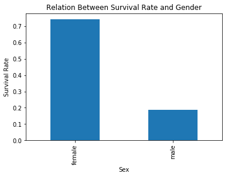

```python
%matplotlib inline
import matplotlib.pyplot as plt

fg_q1 = titanic_df.groupby('Sex')['Survived'].mean().plot(kind = "bar", title = "Relation Between Survival Rate and Gender")
fg_q1.set_ylabel("Survival Rate")
```

Answer 1: Females have a much larger chance (>70%) to survive compared with males(<20%)

Question 2: How about the passengers age? If a passenger is young or old, does he or she have a larger chance to survive?

```python
def age_conv(value):
    if value <= 10:
        return '0-10'
    elif value <= 20:
        return '10-20'
    elif value <= 30:
        return '20-30'
    elif value <= 40:
        return '30-40'
    elif value <= 50:
        return '40-50'
    elif value <= 60:
        return '50-60'
    elif value <= 70:
        return '60-70'
    elif value <= 80:
        return '70-80'
```

```python
titanic_df['Age Range'] = titanic_df['Age'].apply(age_conv)
titanic_df.head()
```

|  | PassengerId | Survived | Pclass | Name | Sex | Age | SibSp | Parch | Ticket | Fare | Cabin | Embarked | Norm_Fare | Survival | Class | Age Range |
| --- | --- | --- | --- | --- | --- | --- | --- | --- | --- | --- | --- | --- | --- | --- | --- | --- |
| 0 | 1 | 0 | 3 | Braund, Mr. Owen Harris | male | 22.0 | 1 | 0 | A/5 21171 | 7.2500 | NaN | S | -0.048707 | Died | Third Class | 20-30 |
| 1 | 2 | 1 | 1 | Cumings, Mrs. John Bradley (Florence Briggs Th... | female | 38.0 | 1 | 0 | PC 17599 | 71.2833 | C85 | C | 0.076277 | Survived | First Class | 30-40 |
| 2 | 3 | 1 | 3 | Heikkinen, Miss. Laina | female | 26.0 | 0 | 0 | STON/O2. 3101282 | 7.9250 | NaN | S | -0.047390 | Survived | Third Class | 20-30 |
| 3 | 4 | 1 | 1 | Futrelle, Mrs. Jacques Heath (Lily May Peel) | female | 35.0 | 1 | 0 | 113803 | 53.1000 | C123 | S | 0.040786 | Survived | First Class | 30-40 |
| 4 | 5 | 0 | 3 | Allen, Mr. William Henry | male | 35.0 | 0 | 0 | 373450 | 8.0500 | NaN | S | -0.047146 | Died | Third Class | 30-40 |

Instead of evaluating different age, assigning an age range to each passenger will help us to see the general trend of age influence on survival rate

```python
age_survived = titanic_df.groupby('Age Range')['Survived'].sum()
age_survived
```

```
Age Range
0-10     38
10-20    44
20-30    84
30-40    69
40-50    33
50-60    17
60-70     4
70-80     1
Name: Survived, dtype: int64
```

```python
age_total=titanic_df['Age Range'].value_counts()
age_total
```

```
20-30    230
30-40    155
10-20    115
40-50     86
0-10      64
50-60     42
60-70     17
70-80      5
Name: Age Range, dtype: int64
```

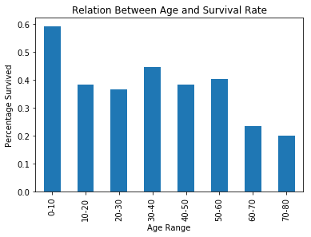

```python
fig1 = (age_survived/age_total).plot(kind='bar')
fig1.set_xlabel('Age Range')
fig1.set_ylabel('Percentage Survived')
fig1.set_title("Relation Between Age and Survival Rate")
```

I've devided the age into different age range. people less than 10 years old have a larger chance to survive than any other age range. However, elder people (60-80) surprizingly have a lower chance to survive. People in their middle age (30-60) have a larger chance to survive compared with younger ones(10-30). One possibility is that people in this range are wealthy people thus they have higher chance to survive.

Questions 3: According to the findings in answer 2, how do age group and fare influence the survival rate? In which age group, higher fare indicates higher rate to survive?

```python
age_fare = titanic_df.groupby(['Age Range', 'Survival'])['Fare'].mean()
age_fare
```

```
Age Range  Survival
0-10       Died        34.479165
           Survived    27.666995
10-20      Died        19.945306
           Survived    44.994986
20-30      Died        20.119032
           Survived    42.537698
30-40      Died        18.267874
           Survived    72.693599
40-50      Died        27.703066
           Survived    62.780942
50-60      Died        29.839168
           Survived    66.738971
60-70      Died        46.341346
           Survived    44.511450
70-80      Died        24.920850
           Survived    30.000000
Name: Fare, dtype: float64
```

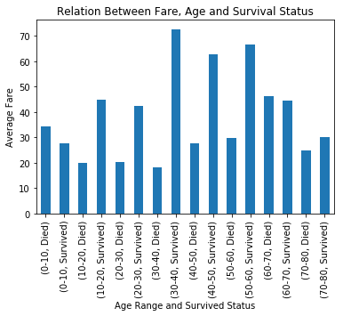

```python
fig2 = age_fare.plot(kind='bar')
fig2.set_xlabel('Age Range and Survived Status')
fig2.set_ylabel('Average Fare')
fig2.set_title("Relation Between Fare, Age and Survival Status")
```

To better understand the relation between survival rate, age range and fare, another two visualizations are provided as below.

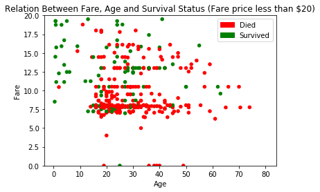

```python
%matplotlib inline
import numpy as np
import matplotlib.patches as mpatches

ax1 = plt.subplot(111)
colors = np.where(titanic_df['Survived'] == 1, 'g', 'r')
plt.scatter(titanic_df['Age'], titanic_df['Fare'], s=20, c=colors)
#plt.figure(figsize=(3,20))
ax1.set_ylim([0,20])
ax1.set_xlabel('Age')
ax1.set_ylabel('Fare')
ax1.set_title("Relation Between Fare, Age and Survival Status (Fare price less than $20)")
red_patch = mpatches.Patch(color='red', label='Died')
green_patch = mpatches.Patch(color='green', label='Survived')
plt.legend(handles=[red_patch, green_patch])
```

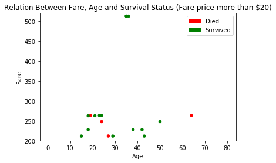

```python
ax1 = plt.subplot(111)
colors = np.where(titanic_df['Survived'] == 1, 'g', 'r')
plt.scatter(titanic_df['Age'], titanic_df['Fare'], s=20, c=colors)
#plt.figure(figsize=(3,20))
ax1.set_ylim([200,520])
ax1.set_xlabel('Age')
ax1.set_ylabel('Fare')
ax1.set_title("Relation Between Fare, Age and Survival Status (Fare price more than $20)")
red_patch = mpatches.Patch(color='red', label='Died')
green_patch = mpatches.Patch(color='green', label='Survived')
plt.legend(handles=[red_patch, green_patch])
```

Limitations of the analysis above: the above analysis tried to find the relation between survival rate, age range and fare price. However, from the data quality analysis, the age information is missing in 177 records of a total of 891 records. This may result in the inaccuracy of the analysis results. The above analysis concluded that people with age range 0-10 have much higher chance to survive (60% survival rate). However, this conclusion may be bias since the total number of people in different age range are not the same. There are less people from 0-10 years (64 people) old than 20-30 year (230 people). Simply comparing the survival rate may not be a good option. If given more passengers' information or their age information is complete, the analysis results should be more convincing.